# STAT451 Final Exam

Author

Sean Steven Alcantara

Published

December 12, 2024

```r
library(tidyverse)
options(digits = 2)
```

# Part 1

**Question:** Read the blog post [Luzmo](https://www.luzmo.com/) blog post [Bad Data Visualization: 9 Examples to Learn From](https://www.luzmo.com/blog/bad-data-visualization). Answer the following questions:

## (a)

**Question:** Describe the kinds of visualization products Luzmo offers. What visualization products have we used in the class that are similar? List two or more

#### Answer:

Luzmo offers dashboarding which offers standard charts such as the pie chart, barplot, line graphs, etc. The charts shown on their website seems to be dynamic. Similar products shown and used during the class are Flourish, R, Microsoft Excel, and Plotly. Although for R you would need to install libraries such as flexdashboard and ggplot2.

## (b)

**Question:** For each bad visualization make a better visualization using a bar graph. You can either make a sketch by hand and take a picture/scan or use any one of the visualization products we have used in the class to make your visualization.

### (i)

**Question: A map with poor use of colors:** Is the second map presenting the data in the first map correctly? (Are the maps presenting the same data?) From the first map, which 3 countries have the highest values? **Make** a bar graph for these 3 countries of the number of US Americans with European ancestry.

#### Answer:

The second map is not presenting the same data from the first map. But the second map is using colors better than the first map because the second map is using a sequential color scheme with a darker color meaning higher percentage of goods sold. The three countries with the highest number of US Americans with European ancestry are

```r
europe_ancestry <- read.csv("CountryMap.csv") %>%
  mutate(Country = as.factor(Country))
```

```r
europe_ancestry_top3 <- europe_ancestry %>%
  arrange(desc(Europe_Ancestry_Count)) %>%
  top_n(3, Europe_Ancestry_Count)
europe_ancestry_top3
```

```
         Country Europe_Ancestry_Count
1 United Kingdom              54000000
2        Germany              45000000
3        Ireland              34000000
```

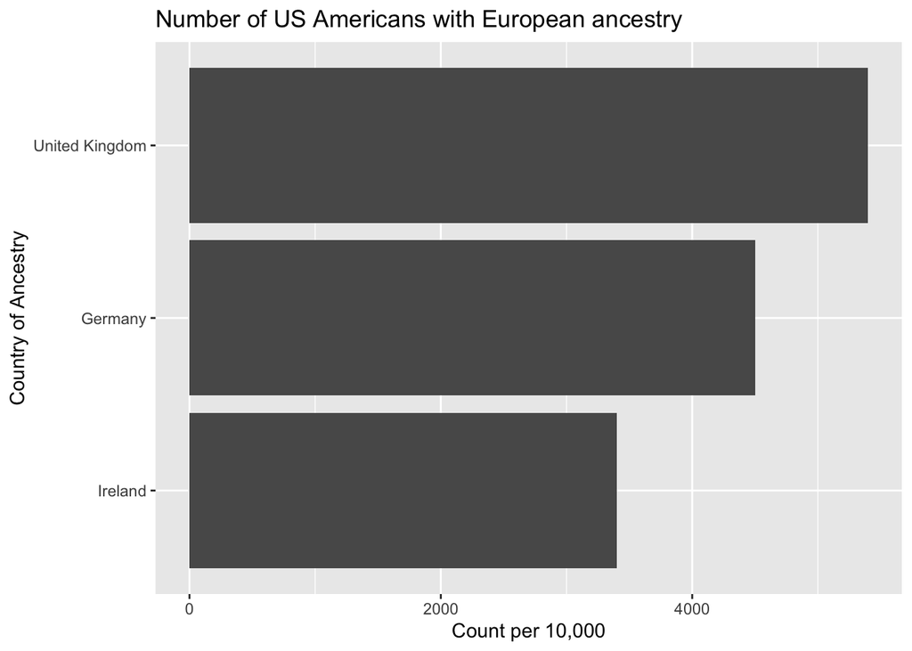

```r
# Arrange left to right based on highest count. Highest count on the left
ggplot(europe_ancestry_top3, aes(x = (Europe_Ancestry_Count / 10000),
       y = fct_reorder(Country, Europe_Ancestry_Count))) +
  geom_bar(stat = "identity") +
  ggtitle("Number of US Americans with European ancestry") +
  xlab("Count per 10,000") +
  ylab("Country of Ancestry")
```

### (ii)

**Question: Improper use of the y-axis:** Is the title of the first bar graph justified? **Make** a corrected bar graph.

#### Answer:

The title is not justified. Trump only won by 1% against Biden in Pennsylvania. The graph also makes it seem like the difference is huge because of a lack of a proper y-axis measurement label.

```r
candidates <- as.factor(c("Trump", "Biden"))
votes <- c(47, 46)
PA_votes_pct <- data.frame(candidates, votes)
PA_votes_pct
```

```
  candidates votes
1      Trump    47
2      Biden    46
```

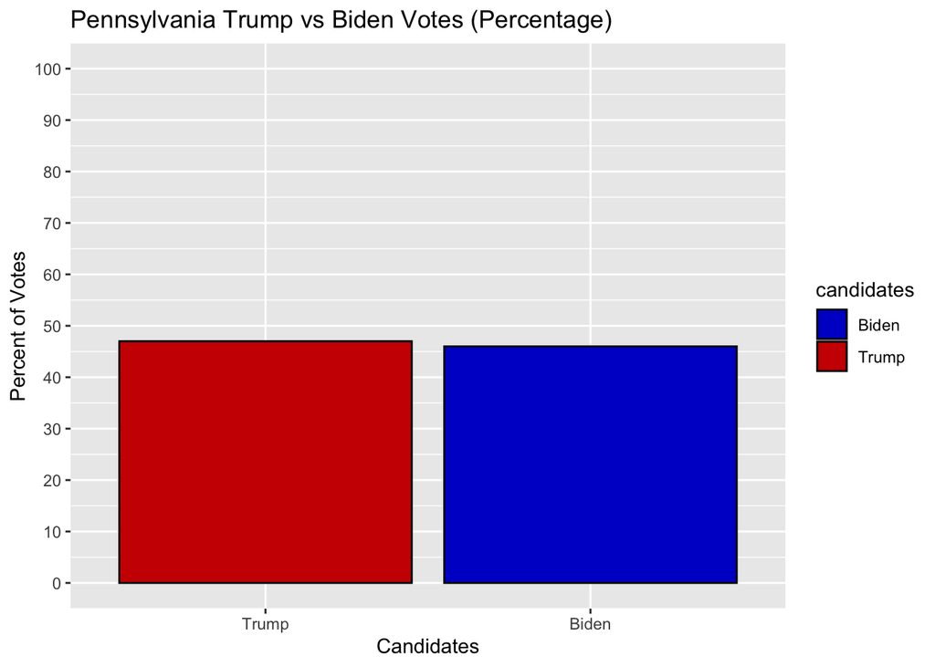

```r
ggplot(PA_votes_pct, aes(x = fct_rev(fct_reorder(candidates, votes)), y = votes)) +
  geom_bar(aes(fill = candidates), stat = "identity", col = "black") +
  scale_y_continuous(breaks = seq(0,100, by = 10), limits = c(0,100)) +
  scale_fill_manual(values=c("blue3","red3")) +
  ylab("Percent of Votes") +
  xlab("Candidates") +
  ggtitle("Pennsylvania Trump vs Biden Votes (Percentage)")
```

### (iii)

**Question:** **Choosing the wrong type of visualization:** Why is the bubble plot a bad choice for the data? Is the map the best choice? **Make** a bar graph for the maximum age in each age group.

#### Answer:

Bubble plot is not a good choice because there seems to be no order. It is easier to tell if the plot is arranged in a way that the countries are in order based on the average of when young people leave the parental household.

```r
ave_age_live_independent <- read.csv("AverageAge_LeaveHousehold_perCountry.csv")
ave_age_live_independent <- ave_age_live_independent %>%
  mutate(Country = as.factor(Country))
head(ave_age_live_independent)
```

```
      Country Age
1     Finland  21
2      Sweden  21
3     Denmark  22
4     Estonia  23
5 Netherlands  23
6      France  23
```

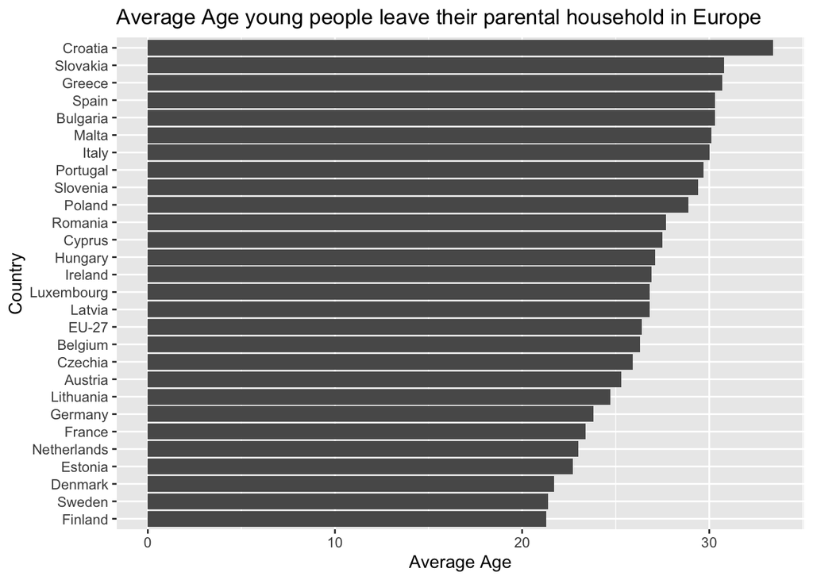

```r
ggplot(ave_age_live_independent, aes(y = fct_reorder(Country, Age), x = Age)) +
  geom_bar(stat = "identity") +
  xlab("Average Age") +
  ylab("Country") +
  ggtitle("Average Age young people leave their parental household in Europe")
```

### (iv)

**Question: The wrong use of legend:** What is the problem with the use of color in the map?

#### Answer:

The problem is that the colors are too close to each other. It is hard to differentiate the different shades of green and the different shades of blue. A better way to fix this is to use a qualitative color scheme, where each app has a different color from the other apps.

### (v)

**Question: Driving misinformation by putting data out of context:** Google search for the population of the US and the population of the United Kingdom. Compute the proportion of serial killers in each country. **Make** a proper bar graph. How different is the proportion of serial killers between the two countries?

#### Answer:

US population: 334.9 Million

United Kingdom population: 68.35 Million

The proportion is better. The US killer proportion is 3x to 4x of the UK Killer proportion as opposed to the original graph where the UK seems like it has such a smaller number of serial killers compared to the US.

```r
killers <- read.csv("Killers_per_country.csv")
killers <- killers %>%
  mutate(Country = as.factor(Country)) |>
  filter(Killer == "Killer")
head(killers)
```

```
         Country Killer_count Killer Population
1  United States         3615 Killer  334900000
2 United Kingdom          190 Killer   68350000
```

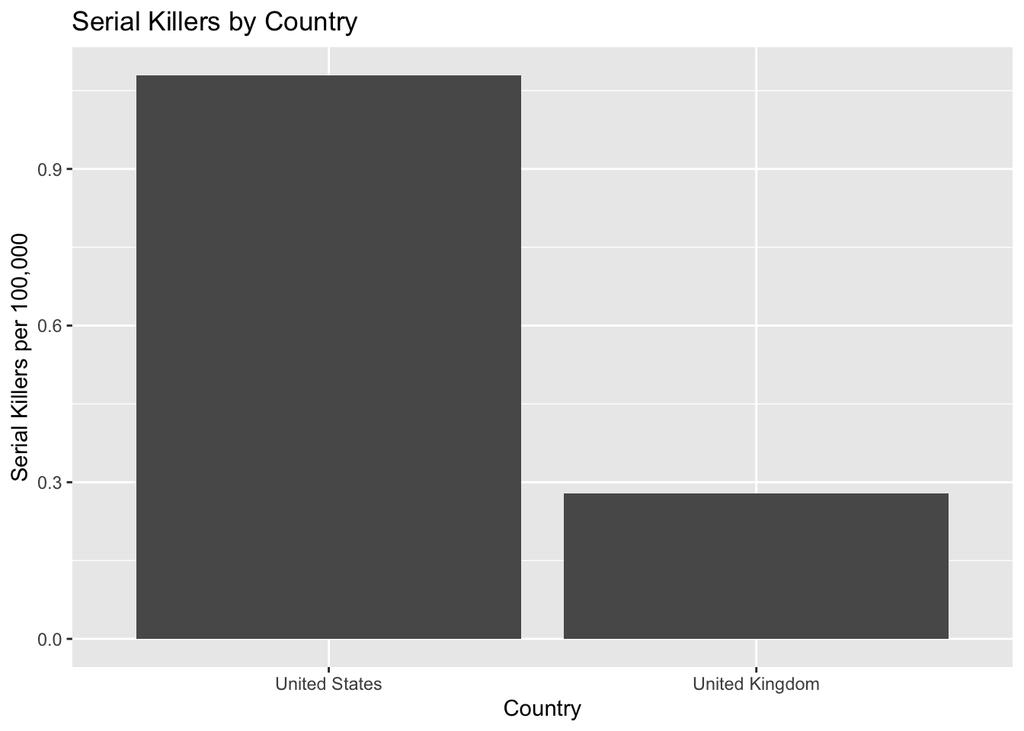

```r
ggplot(killers, aes(x = fct_rev(fct_reorder(Country, Killer_count)),
                       y = (Killer_count/Population) * 100000)) +
  geom_bar(stat = "identity") +
  ylab("Serial Killers per 100,000") +
  xlab("Country") +
  ggtitle("Serial Killers by Country")
```

### (vi)

**Question: Pie charts and donut charts:** Examine the donut chart and bar graph for the Top Causes of Death in National Parks. Explain why the donut chart is not a good visualization and the bar graph is a good visualization.

#### Answer:

For the pie chart the smaller slices are difficult to see. There are too many categories for a pie chart and it is difficult to tell the difference between some of the categories without looking at the numbers. The slices in the pie chart are also not labeled and is relying on color to label the cause of death. Some of the causes of deaths have a really similar color that it is difficult to tell which one you are looking at. The bar graph can be easily arranged in descending order and it is easier to tell which cause of death has a higher value. It is also easier to add the labels next to the bar that corresponds to each cause of death.

### (vii)

**Question: A scatterplot that tells nothing:** Google search three of the companies listed in the visualization and the word internship. For example, McKinsey internsip. You should find [Students | McKinsey & Company](https://www.mckinsey.com/careers/students), click the link. Scroll down to Undergraduate degree and click on [intern.](https://www.mckinsey.com/careers/search-jobs?interestCategory=Serve%20Clients&query=business%20analyst%20intern). Find an internship of interest and provide the link. For example, [Sophomore Summer Business AnalystLinks to an external site.](https://www.mckinsey.com/careers/search-jobs/jobs/sophomoresummerbusinessanalyst-19389). The answer to this question is just the link. (But I would suggest you apply!)

#### Answer:

McKinsey - https://www.mckinsey.com/careers/search-jobs/jobs/businessanalystintern-15275

IBM - https://careers.ibm.com/job/21342411/data-analyst-intern-summer-2025-austin-tx/?codes=WEB_SEARCH_NA

Deloitte - https://apply.deloitte.com/careers/JobDetail/Deloitte-Government-Public-Services-Risk-Financial-Advisory-Intern-Analytics-Summer-2025/186987

# Part 2

**Question:** Data visualization best practices to follow in 2024: Do you agree with 10 ideas in the list? Are there any ideas you would add to the list?

#### Answer:

I agree with the 10 ideas in the list. The only thing I can think of to slightly changing is for item 2. Rather than focusing on the limiting the number of colors, I think it is more important to take note of what kind of color scheme to use. In some cases more colors might be needed if there are many categories that need to be differentiated, in this case make sure to use different colors, and avoid using different shades of the same color.